# Lesson 7 Lecture Example

Rick Davila

5/11/2020

## Lesson 7 - Install packages

#### Install necessary packages using library()

#### Perform data housekeeping - upload, name columns, display to make sure it reads properly, etc.

```r
knitr::opts_chunk$set(echo = TRUE)

library(e1071)
library(xtable)
library("xlsx") # Needed to read data
library(psych) # For geometric mean in Example 5.3
rm(list = ls())
```

```r
exL <- read.xlsx("data-table-B09.xlsx",
                   sheetIndex = 1,
                   colIndex = c(1,2,3,4,5),
                   as.data.frame = TRUE,
                   header = TRUE)
```

#### Assign labels to data columns using names() and attach() commands

```r
names(exL) <- c("fluid_vel", "viscosity","mesh_open","fluid_gas_vel","pressure_drop")
attach(exL)
```

#### Output data to make sure it reads properly

```r
out <- as.data.frame(c(exL))
colnames(out) <- c("fluid_vel", "viscosity","mesh_open","fluid_gas_vel","pressure_drop")
tab <- (xtable(out, digits=c(0,2,1,2,3,1)))
print(tab, type="html")
```

|  | fluid_vel | viscosity | mesh_open | fluid_gas_vel | pressure_drop |
| --- | --- | --- | --- | --- | --- |
| 1 | 2.14 | 10.0 | 0.34 | 1.000 | 28.9 |
| 2 | 4.14 | 10.0 | 0.34 | 1.000 | 31.0 |
| 3 | 8.15 | 10.0 | 0.34 | 1.000 | 26.4 |
| 4 | 2.14 | 10.0 | 0.34 | 0.246 | 27.2 |
| 5 | 4.14 | 10.0 | 0.34 | 0.379 | 26.1 |
| 6 | 8.15 | 10.0 | 0.34 | 0.474 | 23.2 |
| 7 | 2.14 | 10.0 | 0.34 | 0.141 | 19.7 |
| 8 | 4.14 | 10.0 | 0.34 | 0.234 | 22.1 |
| 9 | 8.15 | 10.0 | 0.34 | 0.311 | 22.8 |
| 10 | 2.14 | 10.0 | 0.34 | 0.076 | 29.2 |
| 11 | 4.14 | 10.0 | 0.34 | 0.132 | 23.6 |
| 12 | 8.15 | 10.0 | 0.34 | 0.184 | 23.6 |
| 13 | 2.14 | 2.6 | 0.34 | 0.679 | 24.2 |
| 14 | 4.14 | 2.6 | 0.34 | 0.804 | 22.1 |
| 15 | 8.15 | 2.6 | 0.34 | 0.890 | 20.9 |
| 16 | 2.14 | 2.6 | 0.34 | 0.514 | 17.6 |
| 17 | 4.14 | 2.6 | 0.34 | 0.672 | 15.7 |
| 18 | 8.15 | 2.6 | 0.34 | 0.801 | 15.8 |
| 19 | 2.14 | 2.6 | 0.34 | 0.346 | 14.0 |
| 20 | 4.14 | 2.6 | 0.34 | 0.506 | 17.1 |
| 21 | 8.15 | 2.6 | 0.34 | 0.669 | 18.3 |
| 22 | 2.14 | 2.6 | 0.34 | 1.000 | 33.8 |
| 23 | 4.14 | 2.6 | 0.34 | 1.000 | 31.7 |
| 24 | 8.15 | 2.6 | 0.34 | 1.000 | 28.1 |
| 25 | 5.60 | 1.2 | 0.34 | 0.848 | 18.1 |
| 26 | 5.60 | 1.2 | 0.34 | 0.737 | 16.5 |
| 27 | 5.60 | 1.2 | 0.34 | 0.651 | 15.4 |
| 28 | 5.60 | 1.2 | 0.34 | 0.554 | 15.0 |
| 29 | 4.30 | 2.6 | 0.34 | 0.748 | 19.1 |
| 30 | 4.30 | 2.6 | 0.34 | 0.682 | 16.2 |
| 31 | 4.30 | 2.6 | 0.34 | 0.524 | 16.3 |
| 32 | 4.30 | 2.6 | 0.34 | 0.472 | 15.8 |
| 33 | 4.30 | 2.6 | 0.34 | 0.398 | 15.4 |
| 34 | 5.60 | 10.1 | 0.25 | 0.789 | 19.2 |
| 35 | 5.60 | 10.1 | 0.25 | 0.677 | 8.4 |
| 36 | 5.60 | 10.1 | 0.25 | 0.590 | 15.0 |
| 37 | 5.60 | 10.1 | 0.25 | 0.523 | 12.0 |
| 38 | 5.60 | 10.1 | 0.34 | 0.789 | 21.9 |
| 39 | 5.60 | 10.1 | 0.34 | 0.677 | 21.3 |
| 40 | 5.60 | 10.1 | 0.34 | 0.590 | 21.6 |
| 41 | 5.60 | 10.1 | 0.34 | 0.523 | 19.8 |
| 42 | 4.30 | 10.1 | 0.34 | 0.741 | 21.6 |
| 43 | 4.30 | 10.1 | 0.34 | 0.617 | 17.3 |
| 44 | 4.30 | 10.1 | 0.34 | 0.524 | 20.0 |
| 45 | 4.30 | 10.1 | 0.34 | 0.457 | 18.6 |
| 46 | 2.40 | 10.1 | 0.34 | 0.615 | 22.1 |
| 47 | 2.40 | 10.1 | 0.34 | 0.473 | 14.7 |
| 48 | 2.40 | 10.1 | 0.34 | 0.381 | 15.8 |
| 49 | 2.40 | 10.1 | 0.34 | 0.320 | 13.2 |
| 50 | 5.60 | 10.1 | 0.55 | 0.789 | 30.8 |
| 51 | 5.60 | 10.1 | 0.55 | 0.677 | 27.5 |
| 52 | 5.60 | 10.1 | 0.55 | 0.590 | 25.2 |
| 53 | 5.60 | 10.1 | 0.55 | 0.523 | 22.8 |
| 54 | 2.14 | 112.0 | 0.34 | 0.680 | 41.7 |
| 55 | 4.14 | 112.0 | 0.34 | 0.803 | 33.7 |
| 56 | 8.15 | 112.0 | 0.34 | 0.889 | 29.7 |
| 57 | 2.14 | 112.0 | 0.34 | 0.514 | 41.8 |
| 58 | 4.14 | 112.0 | 0.34 | 0.672 | 37.1 |
| 59 | 8.15 | 112.0 | 0.34 | 0.801 | 40.1 |
| 60 | 2.14 | 112.0 | 0.34 | 0.306 | 42.7 |
| 61 | 4.14 | 112.0 | 0.34 | 0.506 | 48.6 |
| 62 | 8.15 | 112.0 | 0.34 | 0.668 | 42.4 |

```r
# Output data structure and dimensions
str(exL)
```

‘data.frame’: 62 obs. of 5 variables: $ fluid_vel : num 2.14 4.14 8.15 2.14 4.14 8.15 2.14 4.14 8.15 2.14 … $ viscosity : num 10 10 10 10 10 10 10 10 10 10 … $ mesh_open : num 0.34 0.34 0.34 0.34 0.34 0.34 0.34 0.34 0.34 0.34 … $ fluid_gas_vel: num 1 1 1 0.246 0.379 0.474 0.141 0.234 0.311 0.076 … $ pressure_drop: num 28.9 31 26.4 27.2 26.1 23.2 19.7 22.1 22.8 29.2 …

```r
dim(exL)
```

[1] 62 5

#### create multiple least squares model

```r
model <- lm(pressure_drop ~ fluid_vel + viscosity + mesh_open + fluid_gas_vel)

summary(model)
```

Call: lm(formula = pressure_drop ~ fluid_vel + viscosity + mesh_open + fluid_gas_vel)

Residuals: Min 1Q Median 3Q Max -9.9958 -3.3092 -0.2419 3.3924 10.5668

Coefficients: Estimate Std. Error t value Pr(>|t|)  
(Intercept) 5.89453 4.32508 1.363 0.17828  
fluid_vel -0.47790 0.34002 -1.406 0.16530  
viscosity 0.18271 0.01718 10.633 3.78e-15 **mesh_open 35.40284 11.09960 3.190 0.00232** fluid_gas_vel 5.84391 2.90978 2.008 0.04935  
— Signif. codes: 0 ‘**’ 0.001 ’**’ 0.01 ’’ 0.05 ‘.’ 0.1 ’ ’ 1

Residual standard error: 5.014 on 57 degrees of freedom Multiple R-squared: 0.6914, Adjusted R-squared: 0.6697 F-statistic: 31.92 on 4 and 57 DF, p-value: 5.818e-14

```r
xtable(summary(model))
```

|  | Estimate | Std. Error | t value | Pr(>\|t\|) |
| --- | --- | --- | --- | --- |
| (Intercept) | 5.8945253 | 4.32507771 | 1.362872 | 1.782831e-01 |
| fluid_vel | -0.4779013 | 0.34001900 | -1.405514 | 1.652960e-01 |
| viscosity | 0.1827137 | 0.01718375 | 10.632936 | 3.779436e-15 |
| mesh_open | 35.4028387 | 11.09960045 | 3.189560 | 2.316482e-03 |
| fluid_gas_vel | 5.8439137 | 2.90977841 | 2.008371 | 4.935047e-02 |

```r
xtable(anova(model))
```

|  | Df | Sum Sq | Mean Sq | F value | Pr(>F) |
| --- | --- | --- | --- | --- | --- |
| fluid_vel | 1 | 9.595968 | 9.595968 | 0.3817523 | 5.391278e-01 |
| viscosity | 1 | 2839.780203 | 2839.780203 | 112.9737594 | 3.834506e-15 |
| mesh_open | 1 | 258.951631 | 258.951631 | 10.3017618 | 2.183922e-03 |
| fluid_gas_vel | 1 | 101.389947 | 101.389947 | 4.0335528 | 4.935047e-02 |
| Residuals | 57 | 1432.788219 | 25.136635 | NA | NA |

#### make a plot of the multiple least squares model

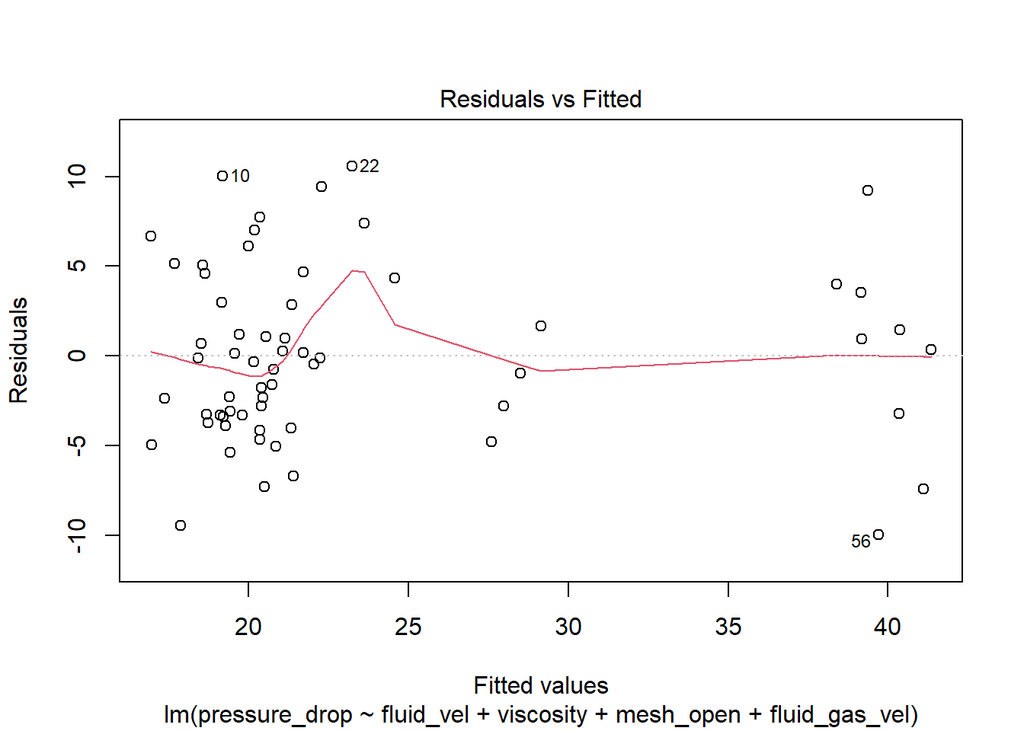

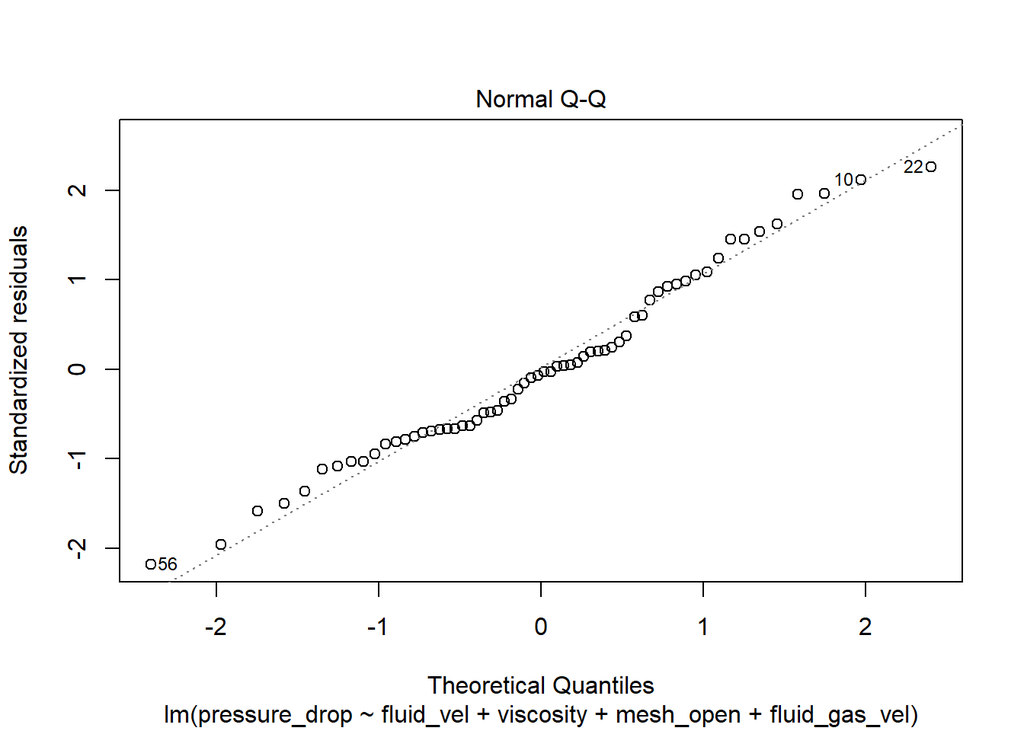

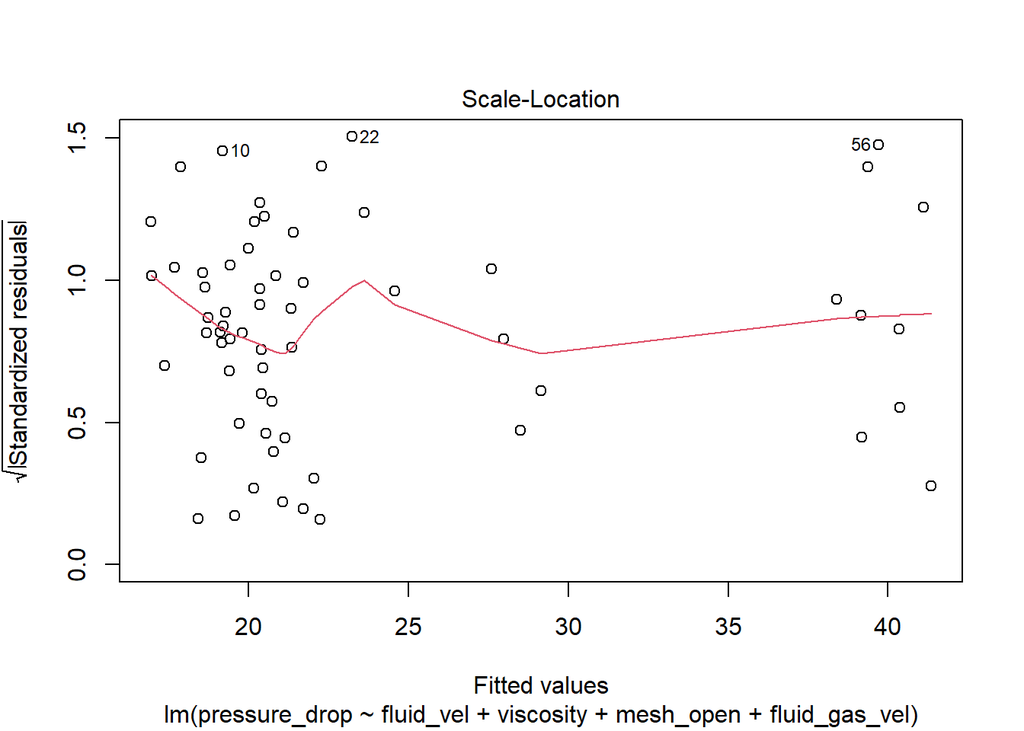

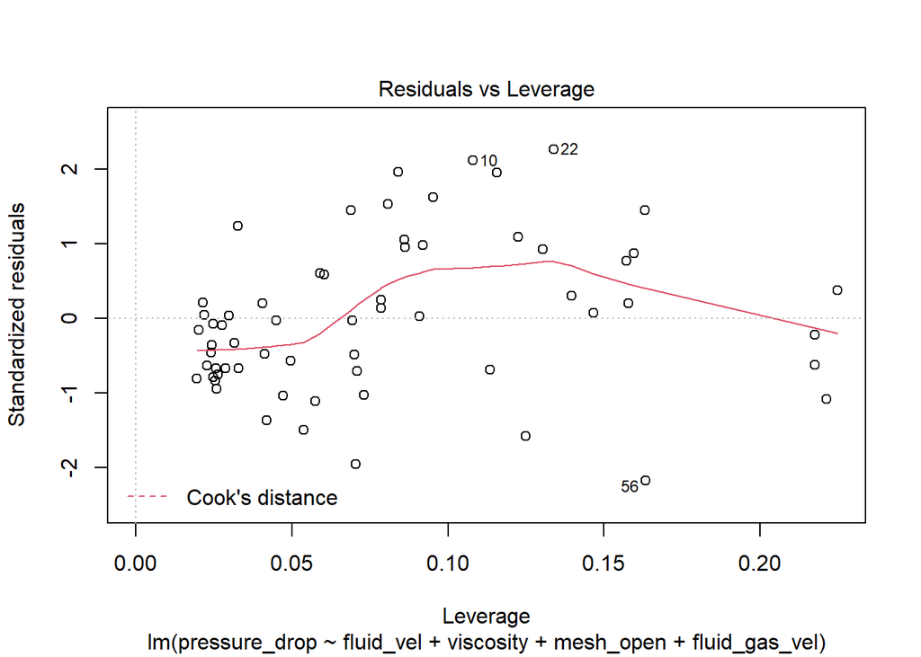

```r
plot(model)
```

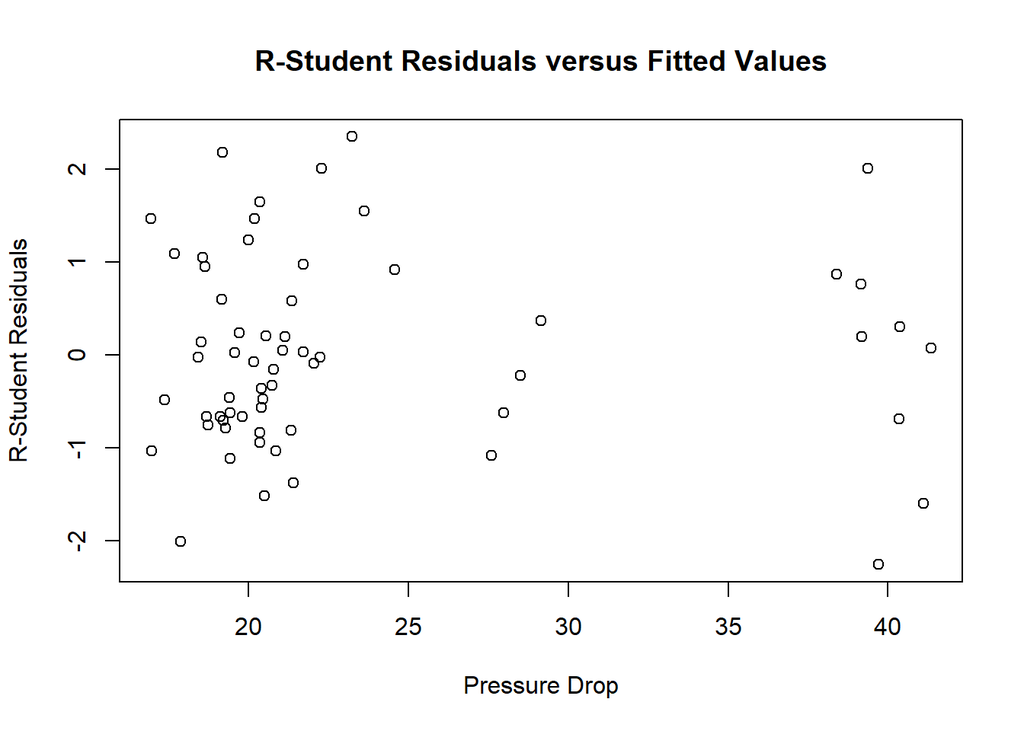

```r
# Let’s look at a plot of the R-student residuals versus the fitted values

R_Student_Residuals <- rstudent(model)
y_hat <- model$fitted.values
plot(y_hat, R_Student_Residuals, ylab = "R-Student Residuals", xlab = "Pressure Drop", main = "R-Student Residuals versus Fitted Values")
```

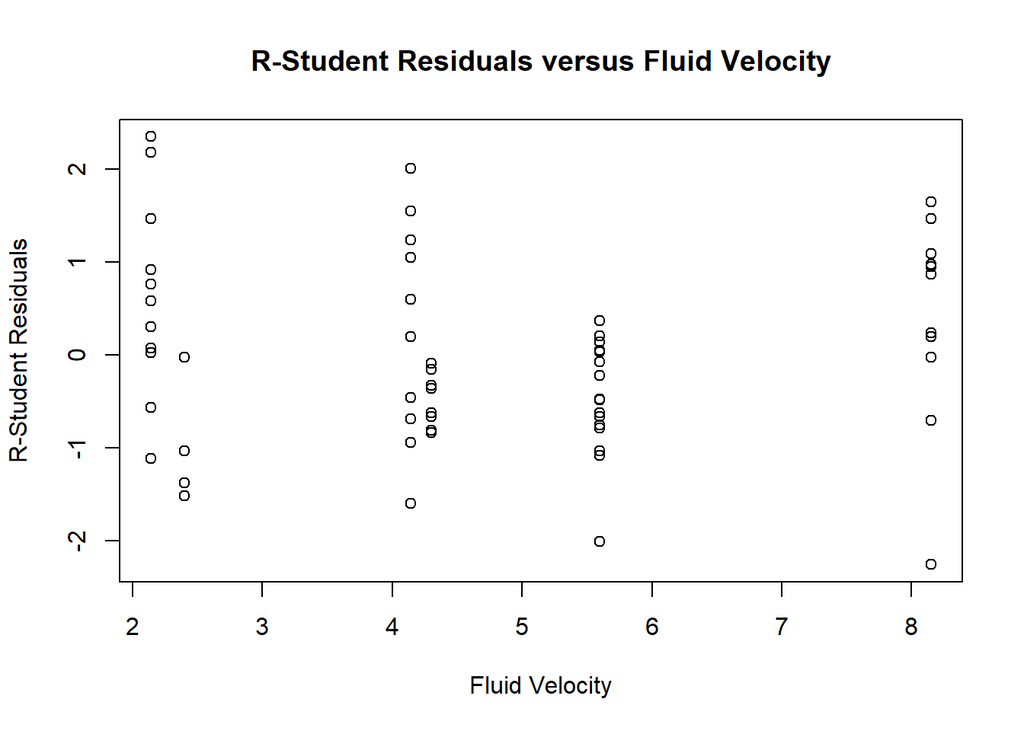

```r
plot(fluid_vel, R_Student_Residuals, ylab = "R-Student Residuals", xlab = "Fluid Velocity", main = "R-Student Residuals versus Fluid Velocity")
```

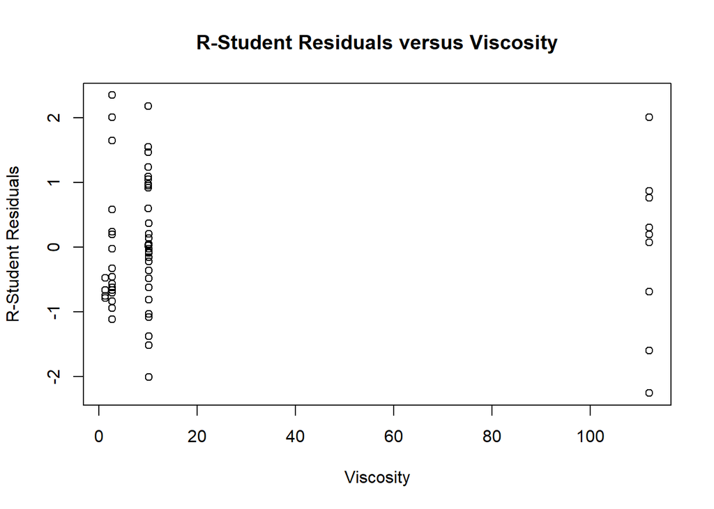

```r
plot(viscosity, R_Student_Residuals, ylab = "R-Student Residuals", xlab = "Viscosity", main = "R-Student Residuals versus Viscosity")
```

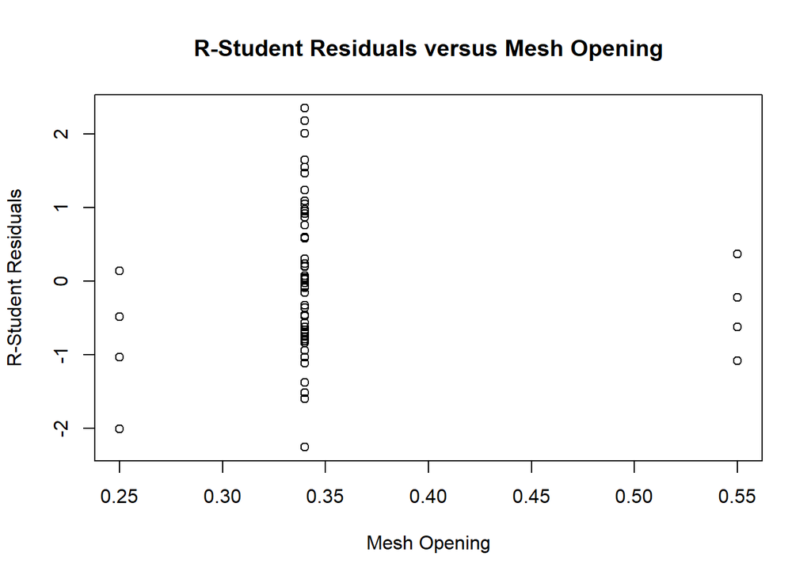

```r
plot(mesh_open, R_Student_Residuals, ylab = "R-Student Residuals", xlab = "Mesh Opening", main = "R-Student Residuals versus Mesh Opening")
```

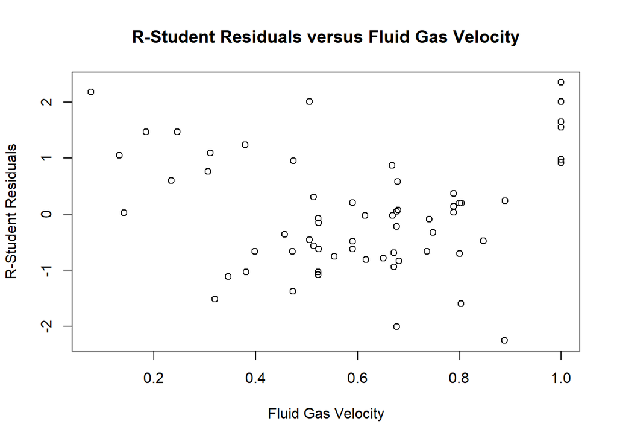

```r
plot(fluid_gas_vel, R_Student_Residuals, ylab = "R-Student Residuals", xlab = "Fluid Gas Velocity", main = "R-Student Residuals versus Fluid Gas Velocity")
```

### Since there’s a huge gap in the residuals versus viscosity data, we’ll try a natural log on the regressor. Redo the exercise above, but, with the lm() using log of vicosity.

```r
model <- lm(pressure_drop ~ fluid_vel + log(viscosity) + mesh_open + fluid_gas_vel)

summary(model)
```

Call: lm(formula = pressure_drop ~ fluid_vel + log(viscosity) + mesh_open + fluid_gas_vel)

Residuals: Min 1Q Median 3Q Max -13.4818 -3.5114 -0.2417 2.9716 12.8961

Coefficients: Estimate Std. Error t value Pr(>|t|)  
(Intercept) -0.8207 4.9007 -0.167 0.86760  
fluid_vel -0.5492 0.3739 -1.469 0.14739  
log(viscosity) 5.0960 0.5574 9.143 9.03e-13 *mesh_open 28.0374 12.1975 2.299 0.02521*  
fluid_gas_vel 10.3162 3.2096 3.214 0.00215 — Signif. codes: 0 ‘**’ 0.001 ’**’ 0.01 ’’ 0.05 ‘.’ 0.1 ’ ’ 1

Residual standard error: 5.514 on 57 degrees of freedom Multiple R-squared: 0.6267, Adjusted R-squared: 0.6005 F-statistic: 23.92 on 4 and 57 DF, p-value: 1.201e-11

```r
xtable(summary(model))
```

|  | Estimate | Std. Error | t value | Pr(>\|t\|) |
| --- | --- | --- | --- | --- |
| (Intercept) | -0.8206807 | 4.9007332 | -0.1674608 | 8.676002e-01 |
| fluid_vel | -0.5492321 | 0.3739394 | -1.4687728 | 1.473920e-01 |
| log(viscosity) | 5.0960394 | 0.5573821 | 9.1428120 | 9.031359e-13 |
| mesh_open | 28.0374015 | 12.1974870 | 2.2986211 | 2.521404e-02 |
| fluid_gas_vel | 10.3162044 | 3.2095719 | 3.2141995 | 2.154800e-03 |

```r
xtable(anova(model))
```

|  | Df | Sum Sq | Mean Sq | F value | Pr(>F) |
| --- | --- | --- | --- | --- | --- |
| fluid_vel | 1 | 9.595968 | 9.595968 | 0.3156013 | 5.764656e-01 |
| log(viscosity) | 1 | 2420.863436 | 2420.863436 | 79.6196421 | 2.063142e-12 |
| mesh_open | 1 | 164.821263 | 164.821263 | 5.4207973 | 2.346952e-02 |
| fluid_gas_vel | 1 | 314.120098 | 314.120098 | 10.3310783 | 2.154800e-03 |
| Residuals | 57 | 1733.105202 | 30.405354 | NA | NA |

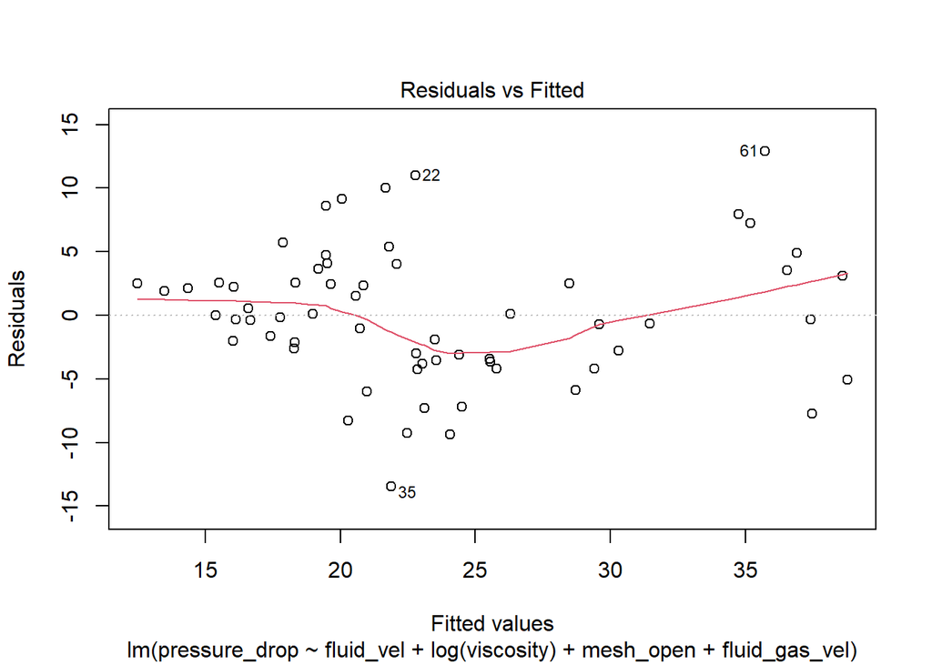

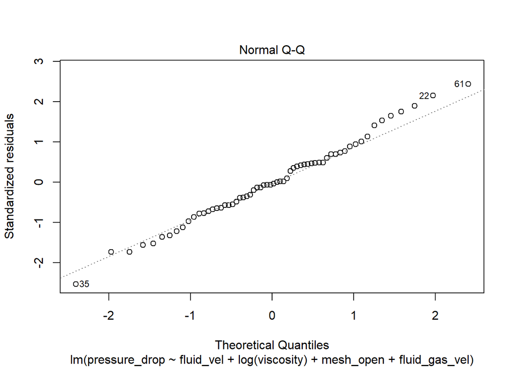

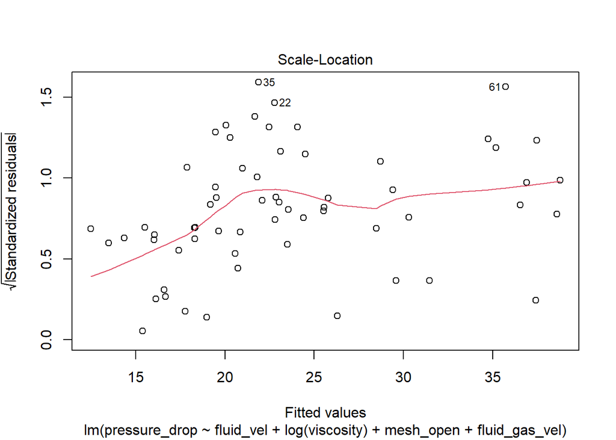

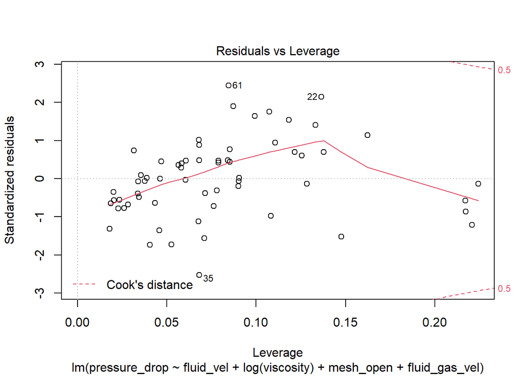

```r
plot(model)
```

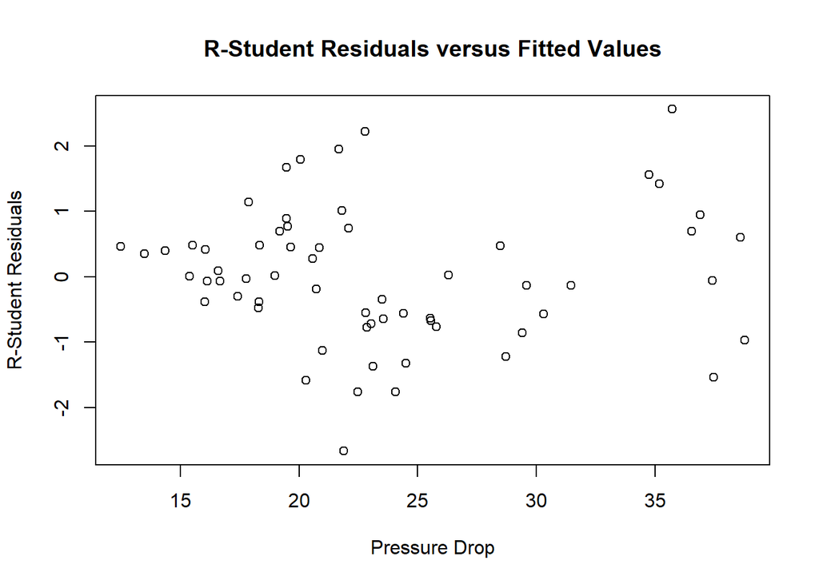

```r
R_Student_Residuals <- rstudent(model)
y_hat <- model$fitted.values
plot(y_hat, R_Student_Residuals, ylab = "R-Student Residuals", xlab = "Pressure Drop", main = "R-Student Residuals versus Fitted Values")
```

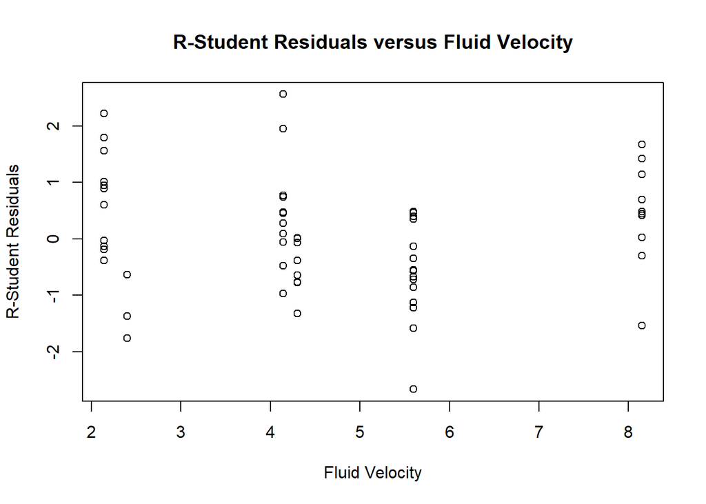

```r
plot(fluid_vel, R_Student_Residuals, ylab = "R-Student Residuals", xlab = "Fluid Velocity", main = "R-Student Residuals versus Fluid Velocity")
```

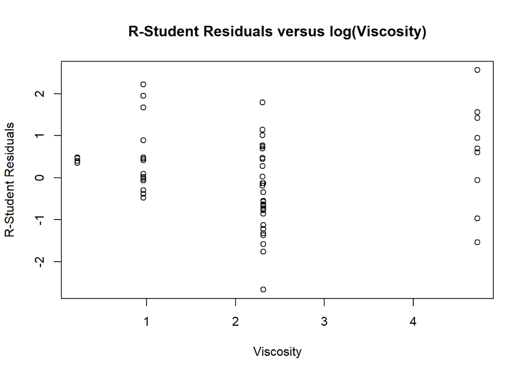

```r
plot(log(viscosity), R_Student_Residuals, ylab = "R-Student Residuals", xlab = "Viscosity", main = "R-Student Residuals versus log(Viscosity)")
```

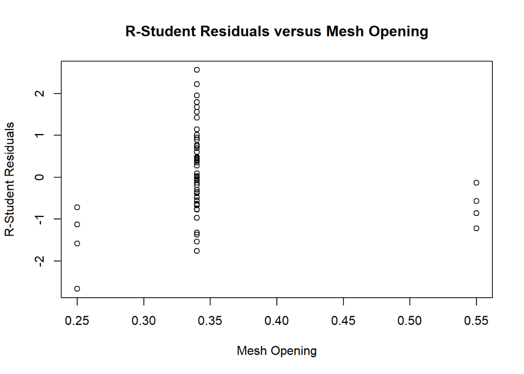

```r
plot(mesh_open, R_Student_Residuals, ylab = "R-Student Residuals", xlab = "Mesh Opening", main = "R-Student Residuals versus Mesh Opening")
```

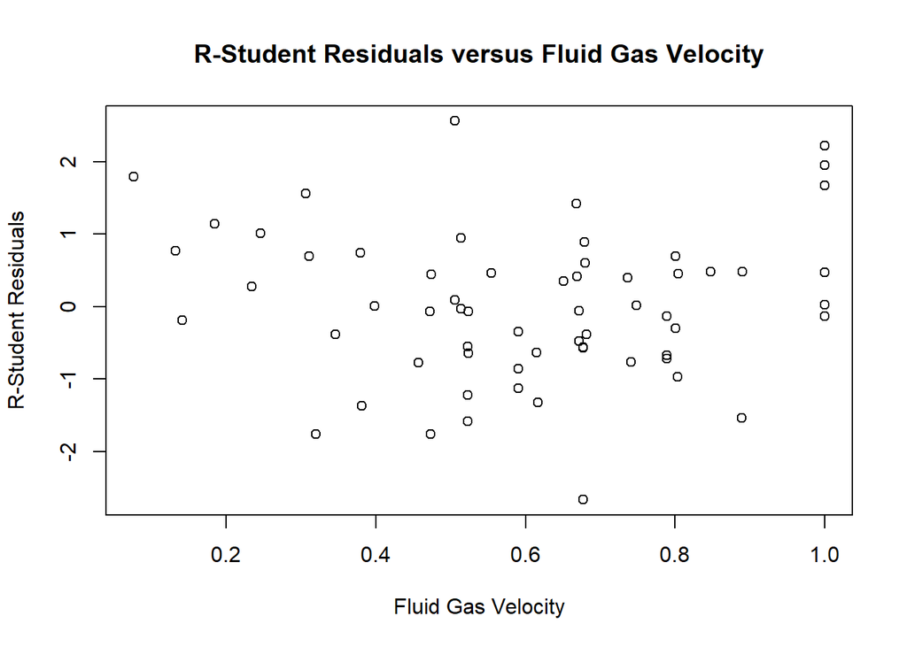

```r
plot(fluid_gas_vel, R_Student_Residuals, ylab = "R-Student Residuals", xlab = "Fluid Gas Velocity", main = "R-Student Residuals versus Fluid Gas Velocity")
```